# Module Five Activity

For the module five activity, you will write Python code to create clear and informative data visualizations from the provided data set `Most-Recent-Cohorts-Field-of-Study.csv`. Your code should be well-organized and reflect a clear understanding of each step in the visualization process.

*Note:* there are two parts to this assignment. Part One is the data visualization coding activity. Part Two is the reflection paper.

Once your code is complete, you will download this notebook as an HTML file by clicking **File**, then **Download As**, then **HTML (.html)** from the Jupyter menu bar. Validate that your code, output, and all six visualizations (rendered as images using the display() function) are visible in the html file before submission.

*Missing Blocks:* Ensure that you have clicked **Run** for all blocks before downloading as an HTML file or the block may be missing from your submission. **Images** must be called using the *display()* function, for example: **display(Image(filename="output/{image_name}.png"))**

Specifically, you must address the items from the rubric criteria.

### Part One: Data Visualization

#### Prepare the given data set for visualization. Consider the following:

- Are there any columns you can remove?
- Are filters or groupings needed?
- Are the data values structured for your chart types?

#### Clean the given data set for visualization using Python. Consider the following:

- Are there any missing or invalid values?
- Are there any unclear column names?
- Are the data types correct for each column (e.g., numeric, categorical, datetime)?

#### Create multiple types of visualizations using Python. Include the following:

- Dendrogram
- PCA scatterplot
- Cluster size distribution
- Feature importance heatmap
- Trend chart
- Scatterplot

*Note:* You will need to ensure that you have created at least one of each of the visual types listed above.

### Part 2: Reflection

*This part is to be completed in a word document, using the output here to answer the topics.*

#### Identify patterns in the data. Consider the following:

- Are there any clear trends, clusters, or outliers visible in your visualizations?
- Are certain variables showing consistent behavior or relationships?
- Are the patterns similar across different visualization types?

#### Draw conclusions from the patterns. Consider the following:

- Are your conclusions clearly based on the patterns you observed?
- Are your findings supported by multiple visuals or data points?

#### Explain how the visualizations validate your findings. Consider the following:

- Are specific chart elements (e.g., color, scale, labels) helping to highlight your findings?
- Are the insights you found something you could not easily see without the visuals?

#### Write a summary of the visualization choices you made. Include the following:

- An explanation of the types of charts you used
- An explanation of the formatting decisions to support visual clarity

*To Begin:* This Python template program has been broken down into segments as a guide for what steps you should do at a minimum to complete this activity. Look for the **# To Do:** comments. These are placeholders for you to provide Python code segments. Fill out all **# To Do:** code segments to complete this program.  
*Once Complete:* Execute a "Kernel restart and run all" to verify that all your code works as a single unit by clicking **Kernel**, then **Restart & Run All** before downloading as html.

*Hint:* If you need to install additional packages, see one of the earlier modules on how to configure and call a requirements.txt file.

## Import the Required Packages

- **pandas (pd):** For reading and manipulating the dataset.
- **MinMaxScaler:** A preprocessing tool from sklearn to normalize data values between 0 and 1.
- **PCA:** Principal Component Analysis (dimensionality reduction) from sklearn for visualizing clusters in 2D.
- **dendrogram, linkage, fcluster:** Tools from scipy for performing hierarchical clustering and visualizing its results.
- **matplotlib.pyplot (plt):** For creating charts and saving visuals.
- **seaborn (sns):** For advanced and visually appealing charts.
- **numpy (np):** For numerical operations like arrays and aggregations.

```python
import pandas as pd   # for reading & manipulating the dataset
from sklearn.preprocessing import MinMaxScaler    # a preprocessing tool from sklearn to normalize data values
                                                                                    # between 0 and 1
from sklearn.decomposition import PCA  # Principal Component Analysis (dimensionality reduction) from
                                                                   # sklearn for visualizing clusters in 2D
from scipy.cluster.hierarchy import dendrogram, linkage, fcluster    # tools from scipy for performing hierarchical clustering & visualizing its results
import matplotlib.pyplot as plt     #  for creating charts & saving visuals
import seaborn as sns    #  for advanced & visually appealing charts
import numpy as np      # for numerical operations like arrays & aggregations

from IPython.display import Image, display # for image rendering in html output

import os  # NEW: create/check output folder for saved PNGs
import warnings  # NEW: optional, helps reduce noisy warnings in output
warnings.filterwarnings("ignore")  # NEW: optional, keeps notebook output clean (can remove if you prefer seeing warnings)

# NEW: ensure output folder exists for saving charts
os.makedirs("output", exist_ok=True)  # ensures saved PNGs go to /output without errors
```

# Part One: Data Visualization

## Loading the Data

*Hints:* Use **pd.read_csv** to read a CSV file and load it into a DataFrame (data). Use **try block** to ensures the program handles errors gracefully if the file cannot be loaded (e.g., missing or incorrect path). Use **exit()** to stop the program if an error occurs.

```python
print("Loading dataset...")

# To Do: Use the given dataset named "Most-Recent-Cohorts-Field-of-Study.csv" for this assignment
# Load this dataset
# For secure coding, put this action in a try/catch block

# NEW: Safety import in case the kernel restarted and the imports cell didn't run yet
# This prevents NameError if this cell is run independently
import pandas as pd

# NEW: Use glob to locate the file in the Codio workspace (e.g., inside /data)
# Codio sometimes places datasets in subfolders
import glob
import os

# NEW: Ensure output folder exists for saving charts later in the notebook
os.makedirs("output", exist_ok=True)

try:
    # NEW: Search recursively for the dataset file
    matches = glob.glob("**/Most-Recent-Cohorts-Field-of-Study.csv", recursive=True)
    if not matches:
        raise FileNotFoundError(
            "Dataset file not found anywhere. Make sure it exists in the Module Five Activity data folder."
        )

    # NEW: Use the first matching path found
    csv_path = matches[0]
    print("Found dataset at:", csv_path)

    # Load dataset into a pandas DataFrame
    data = pd.read_csv(csv_path, low_memory=False)

    print("Dataset loaded successfully.")
    print("Dataset shape:", data.shape)
    display(data.head())

except FileNotFoundError as e:
    # Explicit error for missing dataset
    print("Error:", e)
    raise

except Exception as e:
    # Catch-all for unexpected issues
    print("An unexpected error occurred while loading the dataset:")
    print(e)
    raise
```

```
Loading dataset...
Found dataset at: data/Most-Recent-Cohorts-Field-of-Study.csv
Dataset loaded successfully.
Dataset shape: (229188, 174)
```

|  | UNITID | OPEID6 | INSTNM | CONTROL | MAIN | CIPCODE | CIPDESC | CREDLEV | CREDDESC | IPEDSCOUNT1 | ... | EARN_COUNT_PELL_WNE_5YR | EARN_PELL_WNE_MDN_5YR | EARN_COUNT_NOPELL_WNE_5YR | EARN_NOPELL_WNE_MDN_5YR | EARN_COUNT_MALE_WNE_5YR | EARN_MALE_WNE_MDN_5YR | EARN_COUNT_NOMALE_WNE_5YR | EARN_NOMALE_WNE_MDN_5YR | EARN_COUNT_HIGH_CRED_5YR | EARN_IN_STATE_5YR |
| --- | --- | --- | --- | --- | --- | --- | --- | --- | --- | --- | --- | --- | --- | --- | --- | --- | --- | --- | --- | --- | --- |
| 0 | 100654.0 | 1002 | Alabama A & M University | Public | 1 | 100 | Agriculture, General. | 3 | Bachelor's Degree | NaN | ... | PS | PS | PS | PS | PS | PS | PS | PS | PS | PS |
| 1 | 100654.0 | 1002 | Alabama A & M University | Public | 1 | 101 | Agricultural Business and Management. | 3 | Bachelor's Degree | NaN | ... | PS | PS | PS | PS | PS | PS | PS | PS | PS | PS |
| 2 | 100654.0 | 1002 | Alabama A & M University | Public | 1 | 109 | Animal Sciences. | 3 | Bachelor's Degree | 3.0 | ... | PS | PS | PS | PS | PS | PS | PS | PS | PS | PS |
| 3 | 100654.0 | 1002 | Alabama A & M University | Public | 1 | 110 | Food Science and Technology. | 3 | Bachelor's Degree | 7.0 | ... | PS | PS | PS | PS | PS | PS | PS | PS | PS | PS |
| 4 | 100654.0 | 1002 | Alabama A & M University | Public | 1 | 110 | Food Science and Technology. | 5 | Master's Degree | 4.0 | ... | PS | PS | PS | PS | PS | PS | PS | PS | PS | PS |

5 rows × 174 columns

## Display Dataset Information

*Hints:* Use **data.columns.tolist()** to extract and print all column names. Use **data.index.tolist()** to show the index values of the dataset (e.g., row numbers). Use **data.head()** to display the top 5 rows to give an overview of the data.

```python
print("Column Names:")
# To Do: Print all column names
print(data.columns.tolist())
```

```
Column Names:
['UNITID', 'OPEID6', 'INSTNM', 'CONTROL', 'MAIN', 'CIPCODE', 'CIPDESC', 'CREDLEV', 'CREDDESC', 'IPEDSCOUNT1', 'IPEDSCOUNT2', 'DEBT_ALL_STGP_ANY_N', 'DEBT_ALL_STGP_ANY_MEAN', 'DEBT_ALL_STGP_ANY_MDN', 'DEBT_ALL_STGP_EVAL_N', 'DEBT_ALL_STGP_EVAL_MEAN', 'DEBT_ALL_STGP_EVAL_MDN', 'DEBT_ALL_PP_ANY_N', 'DE…
```

```python
print("Row Index Labels:")
# To Do: Print all row data Labels
print(data.index.tolist())
```

```
Row Index Labels:
[0, 1, 2, 3, 4, 5, 6, 7, 8, 9, 10, 11, 12, 13, 14, 15, 16, 17, 18, 19, 20, 21, 22, 23, 24, 25, 26, 27, 28, 29, 30, 31, 32, 33, 34, 35, 36, 37, 38, 39, 40, 41, 42, 43, 44, 45, 46, 47, 48, 49, 50, 51, 52, 53, 54, 55, 56, 57, 58, 59, 60, 61, 62, 63, 64, 65, 66, 67, 68, 69, 70, 71, 72, 73, 74, 75, 76, 7…
```

```python
print("First 5 Rows of the Dataset:")
# To Do: Print the first 5 rows of the dataset
display(data.head())
```

```
First 5 Rows of the Dataset:
```

|  | UNITID | OPEID6 | INSTNM | CONTROL | MAIN | CIPCODE | CIPDESC | CREDLEV | CREDDESC | IPEDSCOUNT1 | ... | EARN_COUNT_PELL_WNE_5YR | EARN_PELL_WNE_MDN_5YR | EARN_COUNT_NOPELL_WNE_5YR | EARN_NOPELL_WNE_MDN_5YR | EARN_COUNT_MALE_WNE_5YR | EARN_MALE_WNE_MDN_5YR | EARN_COUNT_NOMALE_WNE_5YR | EARN_NOMALE_WNE_MDN_5YR | EARN_COUNT_HIGH_CRED_5YR | EARN_IN_STATE_5YR |
| --- | --- | --- | --- | --- | --- | --- | --- | --- | --- | --- | --- | --- | --- | --- | --- | --- | --- | --- | --- | --- | --- |
| 0 | 100654.0 | 1002 | Alabama A & M University | Public | 1 | 100 | Agriculture, General. | 3 | Bachelor's Degree | NaN | ... | PS | PS | PS | PS | PS | PS | PS | PS | PS | PS |
| 1 | 100654.0 | 1002 | Alabama A & M University | Public | 1 | 101 | Agricultural Business and Management. | 3 | Bachelor's Degree | NaN | ... | PS | PS | PS | PS | PS | PS | PS | PS | PS | PS |
| 2 | 100654.0 | 1002 | Alabama A & M University | Public | 1 | 109 | Animal Sciences. | 3 | Bachelor's Degree | 3.0 | ... | PS | PS | PS | PS | PS | PS | PS | PS | PS | PS |
| 3 | 100654.0 | 1002 | Alabama A & M University | Public | 1 | 110 | Food Science and Technology. | 3 | Bachelor's Degree | 7.0 | ... | PS | PS | PS | PS | PS | PS | PS | PS | PS | PS |
| 4 | 100654.0 | 1002 | Alabama A & M University | Public | 1 | 110 | Food Science and Technology. | 5 | Master's Degree | 4.0 | ... | PS | PS | PS | PS | PS | PS | PS | PS | PS | PS |

5 rows × 174 columns

## Inspect and Select Numeric Columns

*Hints:* Use **select_dtypes()** to filter columns with numeric data types (float64 and int64). Removes columns like **UNITID** and **OPEID6**, which are not useful for clustering. Use **dropna()** to remove rows with missing values to clean data for clustering, see also module three sample for additional cleaning examples. Use error handling **try blocks** to ensures the program stops if the column selection fails.

```python
print("Inspecting dataset to select numeric columns for clustering...")
# To Do: In a try/catch block, exclude identifiers 'UNITID' and 'OPEID6',
#        then print the numeric columns selected for clustering and also print the data for clustering in rows & columns

try:
    # Select numeric columns only (int64 and float64)
    numeric_data = data.select_dtypes(include=["int64", "float64"])

    # Drop identifier columns if they exist (not useful for clustering)
    columns_to_drop = ["UNITID", "OPEID6"]
    numeric_data = numeric_data.drop(
        columns=[col for col in columns_to_drop if col in numeric_data.columns]
    )

    # NEW: Handle IPEDS privacy-suppressed values (e.g., "PS") by coercing to NaN
    # This ensures all remaining values are truly numeric
    numeric_data = numeric_data.apply(pd.to_numeric, errors="coerce")

    # Remove rows with missing or invalid values to prepare clean clustering data
    numeric_data = numeric_data.dropna()

    # Display results
    print("Numeric columns selected for clustering:")
    print(numeric_data.columns.tolist())

    print("\nShape of clustering dataset (rows, columns):")
    print(numeric_data.shape)

    display(numeric_data.head())

except Exception as e:
    print("Error occurred while selecting numeric columns for clustering:")
    print(e)
    exit()
```

```
Inspecting dataset to select numeric columns for clustering...
Numeric columns selected for clustering:
['MAIN', 'CIPCODE', 'CREDLEV', 'IPEDSCOUNT1', 'IPEDSCOUNT2', 'DISTANCE']

Shape of clustering dataset (rows, columns):
(184861, 6)
```

|  | MAIN | CIPCODE | CREDLEV | IPEDSCOUNT1 | IPEDSCOUNT2 | DISTANCE |
| --- | --- | --- | --- | --- | --- | --- |
| 2 | 1 | 109 | 3 | 3.0 | 9.0 | 1 |
| 3 | 1 | 110 | 3 | 7.0 | 10.0 | 1 |
| 4 | 1 | 110 | 5 | 4.0 | 6.0 | 1 |
| 5 | 1 | 110 | 6 | 2.0 | 4.0 | 1 |
| 7 | 1 | 199 | 3 | 6.0 | 6.0 | 1 |

## Normalize the Data

*Hints:* Use **MinMaxScaler()** to scale data values between 0 and 1, ensuring all features are on the same scale. Use **fit_transform()** to fit the scaler to the data and transform it.

```python
print("Normalizing the data using MinMaxScaler...")
# To Do: in a try/catch block, normalize the data using MinMaxScaler

try:
    # NEW: Defensive check to ensure there is data to normalize
    if numeric_data.empty:
        raise ValueError("numeric_data is empty. Cannot perform normalization.")

    # Initialize the MinMaxScaler
    # MinMaxScaler scales all features to the range [0, 1],
    # which is important for distance-based methods like clustering and PCA
    scaler = MinMaxScaler()

    # Fit the scaler to the numeric data and transform it
    normalized_data = scaler.fit_transform(numeric_data)

    # Convert the normalized array back into a DataFrame
    normalized_df = pd.DataFrame(
        normalized_data,
        columns=numeric_data.columns,
        index=numeric_data.index
    )

    print("Data normalization completed successfully.")
    print("Shape of normalized dataset:", normalized_df.shape)
    display(normalized_df.head())

except Exception as e:
    print("Error occurred during data normalization:")
    print(e)
    exit()
```

```
Normalizing the data using MinMaxScaler...
Data normalization completed successfully.
Shape of normalized dataset: (184861, 6)
```

|  | MAIN | CIPCODE | CREDLEV | IPEDSCOUNT1 | IPEDSCOUNT2 | DISTANCE |
| --- | --- | --- | --- | --- | --- | --- |
| 2 | 1.0 | 0.001698 | 0.285714 | 0.000330 | 0.000937 | 0.0 |
| 3 | 1.0 | 0.001886 | 0.285714 | 0.000771 | 0.001041 | 0.0 |
| 4 | 1.0 | 0.001886 | 0.571429 | 0.000440 | 0.000625 | 0.0 |
| 5 | 1.0 | 0.001886 | 0.714286 | 0.000220 | 0.000416 | 0.0 |
| 7 | 1.0 | 0.018676 | 0.285714 | 0.000661 | 0.000625 | 0.0 |

## Perform Hierarchical Clustering

*Hints:* Use **linkage()** to compute hierarchical clusters using **Ward's** method, which minimizes variance between clusters. Limit clustering to the first 1000 rows for performance. Use **fcluster()** to assign cluster labels to data points based on the number of clusters (max_clusters).

```python
print("Performing hierarchical clustering using Ward's method...")
# To Do: in a try/catch block use the Ward's method to perform hierarchical clustering, limit max clusters to 4.

try:
    max_clusters = 4

    # Limit rows for performance (as instructed)
    clustering_input = normalized_df.iloc[:1000, :]

    # NEW: Defensive check (Ward linkage needs at least 2 rows)
    if clustering_input.shape[0] < 2:
        raise ValueError("Not enough rows to perform hierarchical clustering (need at least 2).")

    # NEW: Convert to NumPy array for SciPy (often more stable/faster than passing a DataFrame)
    clustering_array = clustering_input.to_numpy()

    # Compute linkage matrix using Ward's method
    Z = linkage(clustering_array, method="ward")

    # Assign cluster labels (1..max_clusters)
    cluster_labels = fcluster(Z, t=max_clusters, criterion="maxclust")

    print("Hierarchical clustering completed successfully.")
    print("Rows clustered:", clustering_input.shape[0])
    print("Number of clusters requested:", max_clusters)
    print("Cluster label counts:", pd.Series(cluster_labels).value_counts().sort_index().to_dict())

except Exception as e:
    print("Error occurred during hierarchical clustering:")
    print(e)
    exit()
```

```
Performing hierarchical clustering using Ward's method...
Hierarchical clustering completed successfully.
Rows clustered: 1000
Number of clusters requested: 4
Cluster label counts: {1: 202, 2: 370, 3: 208, 4: 220}
```

## Generate, Save, and Output Visualizations

Each visualization is created, saved and displayed, with text output provided before and after.

### Dendrogram

*Hints:* A dendrogram displays the hierarchical structure of clusters. Save the image as **dendrogram.png**. Use **display()** to render the image for html file output. Do not use an html image tag in the markdown, or the image will not print in the html download.

```python
print("Creating dendrogram to visualize hierarchical clustering...")
# To Do: Create a dendrogram to visualize hierarchical clustering, and save the dendrogram into a png file under the 'output' folder.

try:
    import os

    # Ensure output folder exists
    os.makedirs("output", exist_ok=True)

    # NEW: Defensive check to ensure linkage matrix exists
    if "Z" not in globals():
        raise NameError("Linkage matrix Z not found. Run the clustering step before this cell.")

    # Create the dendrogram figure
    plt.figure(figsize=(12, 6))

    # NEW: truncate_mode improves readability for large datasets
    dendrogram(
        Z,
        no_labels=True,
        truncate_mode="lastp",
        p=30,  # show only the last 30 merged clusters for clarity
        color_threshold=None
    )

    # Add clear labeling for readability
    plt.title("Hierarchical Clustering Dendrogram (Ward's Method)")
    plt.xlabel("Cluster Merge Index (Truncated)")
    plt.ylabel("Distance")

    # Save and close figure
    dendrogram_path = "output/dendrogram.png"
    plt.tight_layout()
    plt.savefig(dendrogram_path, dpi=300)
    plt.close()

    print(f"Dendrogram saved to: {dendrogram_path}")

except Exception as e:
    print("Error occurred while creating/saving the dendrogram:")
    print(e)
    exit()
```

```
Creating dendrogram to visualize hierarchical clustering...
Dendrogram saved to: output/dendrogram.png
```

```
Dendrogram visualization display...
```

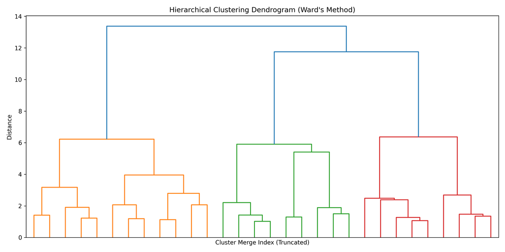

```python
print("Dendrogram visualization display...")
# To Do: output the image using the display() function, for example: display(Image(filename="output/scatter_plot.png"))
display(Image(filename="output/dendrogram.png"))
```

### PCA Scatter Plot

*Hints:* A PCA scatter plot projects high-dimensional data into 2D using PCA for visualization. Save the image as **pca_scatter_plot.png**. Use **display()** to render the image for html file output. Do not use an html image tag in the markdown, or the image will not print in the html download.

```python
print("Creating scatter plot (PCA Reduced) to visualize clusters in 2D...")
# To Do: Create a PCA Scatter Plot to visualize clusters in 2D, and save the PCA Scatter Plot into a png file under the 'output' folder.

try:
    import os

    # Ensure output folder exists
    os.makedirs("output", exist_ok=True)

    # NEW: Defensive checks
    if "normalized_df" not in globals() or "cluster_labels" not in globals():
        raise NameError("Required data not found. Ensure normalization and clustering steps ran successfully.")

    # Use the same rows used for clustering
    pca_input = normalized_df.iloc[:len(cluster_labels), :]

    # NEW: Convert to NumPy array for PCA stability
    pca_array = pca_input.to_numpy()

    # Run PCA to reduce to 2 components
    pca = PCA(n_components=2, random_state=42)
    pca_components = pca.fit_transform(pca_array)

    # Build a DataFrame for plotting
    pca_df = pd.DataFrame(
        pca_components,
        columns=["PC1", "PC2"],
        index=pca_input.index
    )
    pca_df["Cluster"] = cluster_labels

    # Create scatter plot
    plt.figure(figsize=(10, 6))
    sns.scatterplot(
        data=pca_df,
        x="PC1",
        y="PC2",
        hue="Cluster",
        palette="tab10",
        alpha=0.8
    )

    # NEW: Include explained variance in the title (helps interpretation)
    explained_var = pca.explained_variance_ratio_.sum() * 100
    plt.title(f"PCA Scatter Plot (2D) — {explained_var:.2f}% Variance Explained")
    plt.xlabel("Principal Component 1")
    plt.ylabel("Principal Component 2")
    plt.legend(title="Cluster", loc="best")

    # Save and close figure
    pca_path = "output/pca_scatter_plot.png"
    plt.tight_layout()
    plt.savefig(pca_path, dpi=300)
    plt.close()

    print(f"PCA scatter plot saved to: {pca_path}")
    print("Explained variance ratio:", pca.explained_variance_ratio_)

except Exception as e:
    print("Error occurred while creating/saving the PCA scatter plot:")
    print(e)
    exit()
```

```
Creating scatter plot (PCA Reduced) to visualize clusters in 2D...
PCA scatter plot saved to: output/pca_scatter_plot.png
Explained variance ratio: [0.37887545 0.35607884]
```

```
PCA scatter plot visualization display...
```

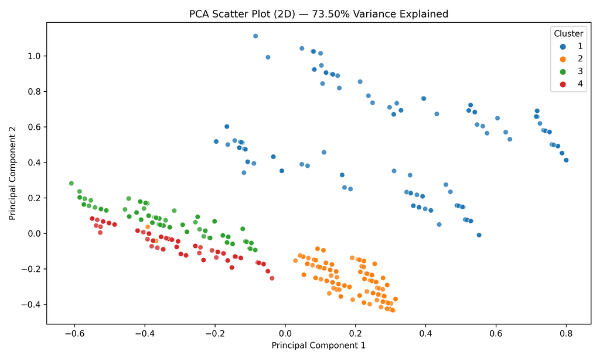

```python
print("PCA scatter plot visualization display...")
# To Do: output the image using the display() function, for example: display(Image(filename="output/pca_scatter_plot.png"))
display(Image(filename="output/pca_scatter_plot.png"))
```

### Cluster Size Distribution

*Hints:* A cluster size distribution displays the population size of each cluster. Save the image as **cluster_size.png**. Use **display()** to render the image for html file output. Do not use an html image tag in the markdown, or the image will not print in the html download.

```python
print("Creating cluster size distribution chart to analyze cluster populations...")
# To Do: Create a cluster size distribution chart, and save it into a png file under the 'output' folder.

try:
    import os

    # Ensure output folder exists
    os.makedirs("output", exist_ok=True)

    # Count how many points are in each cluster
    cluster_counts = pd.Series(cluster_labels).value_counts().sort_index()

    # Plot the distribution
    plt.figure(figsize=(8, 5))
    sns.barplot(
        x=cluster_counts.index.astype(str),
        y=cluster_counts.values
    )

    plt.title("Cluster Size Distribution")
    plt.xlabel("Cluster Label")
    plt.ylabel("Number of Records")

    # Save and close figure
    cluster_size_path = "output/cluster_size.png"
    plt.tight_layout()
    plt.savefig(cluster_size_path, dpi=300)
    plt.close()

    print(f"Cluster size distribution chart saved to: {cluster_size_path}")
    print("Cluster counts:", cluster_counts.to_dict())

except Exception as e:
    print("Error occurred while creating/saving the cluster size distribution chart:")
    print(e)
    exit()
```

```
Creating cluster size distribution chart to analyze cluster populations...
Cluster size distribution chart saved to: output/cluster_size.png
Cluster counts: {1: 202, 2: 370, 3: 208, 4: 220}
```

```
Cluster size distribution visualization display...
```

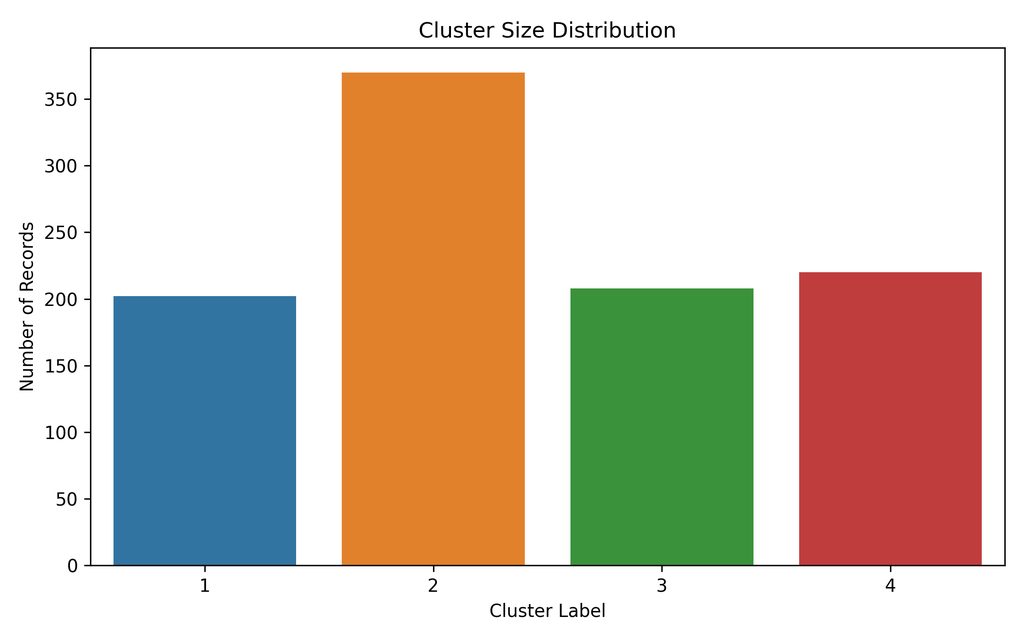

```python
print("Cluster size distribution visualization display...")
# To Do: output the image using the display() function, for example: display(Image(filename="output/cluster_size.png"))
display(Image(filename="output/cluster_size.png"))
```

### Feature Importance Heatmap

*Hints:* A feature importance heatmap highlights the average feature values for each cluster. Save the image as **heatmap.png**. Use **display()** to render the image for html file output. Do not use an html image tag in the markdown, or the image will not print in the html download.

```python
print("Creating feature importance heatmap to show mean feature values by cluster...")
# To Do: Create a feature importance heatmap, and save it into a png file under the 'output' folder.

try:
    import os

    # Ensure output folder exists
    os.makedirs("output", exist_ok=True)

    # Align normalized data with cluster labels
    heatmap_df = normalized_df.iloc[:len(cluster_labels), :].copy()
    heatmap_df["Cluster"] = cluster_labels

    # Compute mean feature values per cluster
    cluster_feature_means = heatmap_df.groupby("Cluster").mean()

    # Create heatmap
    plt.figure(figsize=(14, 8))
    sns.heatmap(
        cluster_feature_means,
        cmap="viridis",
        linewidths=0.5,
        linecolor="white"
    )

    plt.title("Feature Importance Heatmap (Mean Normalized Values by Cluster)")
    plt.xlabel("Features")
    plt.ylabel("Cluster")

    # Save and close figure
    heatmap_path = "output/heatmap.png"
    plt.tight_layout()
    plt.savefig(heatmap_path, dpi=300)
    plt.close()

    print(f"Feature importance heatmap saved to: {heatmap_path}")

except Exception as e:
    print("Error occurred while creating/saving the feature importance heatmap:")
    print(e)
    exit()
```

```
Creating feature importance heatmap to show mean feature values by cluster...
Feature importance heatmap saved to: output/heatmap.png
```

```
Feature important heatmap visualization display...
```

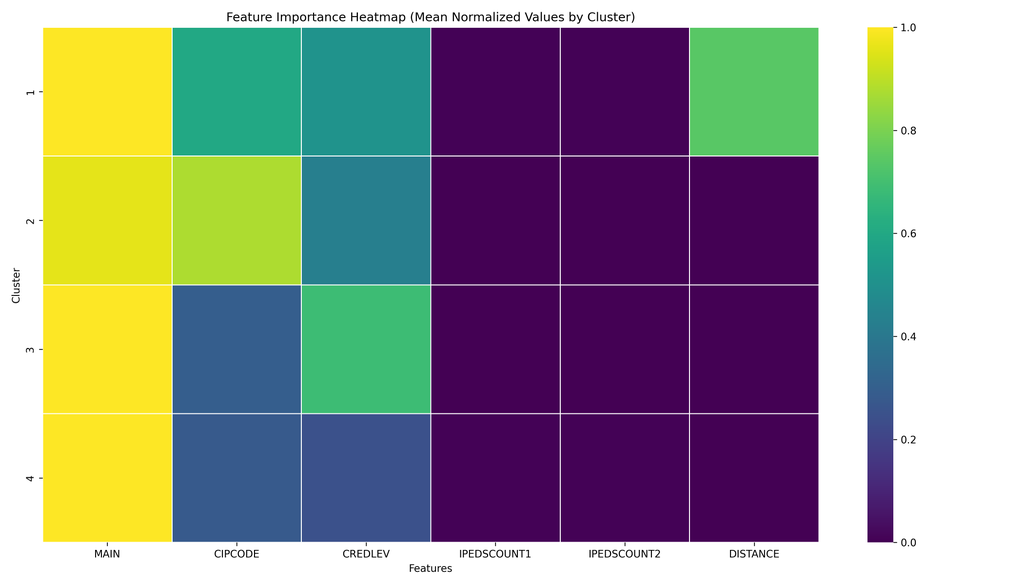

```python
print("Feature important heatmap visualization display...")
# To Do: output the image using the display() function, for example: display(Image(filename="output/heatmap.png"))
display(Image(filename="output/heatmap.png"))
```

### Trend Chart

*Hints:* A trend chart plots trends in a numeric feature across clusters. Save the image as **trend_chart.png**. Use **display()** to render the image for html file output. Do not use an html image tag in the markdown, or the image will not print in the html download.

```python
print("Creating trend chart to analyze a numeric feature across clusters...")
# To Do: Create a trend chart to analyze a numeric feature across clusters, and save it into a png file under the 'output' folder.

try:
    import os

    # Ensure output folder exists
    os.makedirs("output", exist_ok=True)

    # Align raw data to the same rows used for clustering
    trend_raw = data.iloc[:len(cluster_labels), :].copy()
    trend_raw["Cluster"] = cluster_labels

    # Try to find a "time" column (common names)
    candidate_time_cols = ["YEAR", "Year", "year", "CohortYear", "cohort_year", "TERM_YEAR", "term_year"]
    time_col = next((c for c in candidate_time_cols if c in trend_raw.columns), None)

    # Identify numeric columns (exclude ID-like columns if present)
    numeric_cols = trend_raw.select_dtypes(include=["int64", "float64"]).columns.tolist()
    for drop_col in ["UNITID", "OPEID6"]:
        if drop_col in numeric_cols:
            numeric_cols.remove(drop_col)

    if len(numeric_cols) == 0:
        raise ValueError("No numeric columns available to build a trend chart.")

    # NEW: Avoid low-information columns/codes for the trend feature
    # (Old) bad_cols = {"MAIN", "CIPCODE", "CREDLEV"}  # common “not helpful” numeric columns for trending
    # NEW: Expand bad_cols to reduce the chance we pick an identifier/coded column by accident
    bad_cols = {"MAIN", "CIPCODE", "CREDLEV", "CONTROL", "UNITID", "OPEID6", "IPEDSCOUNT1"}

    filtered_cols = [c for c in numeric_cols if c not in bad_cols]

    # NEW: If filtering removes everything, fall back to numeric_cols
    if len(filtered_cols) == 0:
        filtered_cols = numeric_cols

    # NEW: Pick the numeric feature with the most variance (more informative than "first column")
    tmp = trend_raw[filtered_cols].dropna()

    # NEW: Print top variance candidates (helps justify feature selection / reflection)
    if not tmp.empty:
        top_var = tmp.var().sort_values(ascending=False).head(5)
        print("Top variance numeric candidates:", top_var.to_dict())

    feature_col = tmp.var().sort_values(ascending=False).index[0] if not tmp.empty else filtered_cols[0]

    if time_col is not None:
        # Ensure time column is numeric for sorting/grouping
        trend_raw[time_col] = pd.to_numeric(trend_raw[time_col], errors="coerce")

        # Drop rows where time or feature is missing
        plot_df = trend_raw.dropna(subset=[time_col, feature_col])

        # Compute mean feature over time per cluster
        grouped = (
            plot_df.groupby([time_col, "Cluster"])[feature_col]
            .mean()
            .reset_index()
            .sort_values(time_col)
        )

        # Plot lines: one per cluster
        plt.figure(figsize=(10, 6))
        sns.lineplot(
            data=grouped,
            x=time_col,
            y=feature_col,
            hue="Cluster",
            marker="o"
        )

        plt.title(f"Trend Chart: Mean {feature_col} Over {time_col} by Cluster")
        plt.xlabel(time_col)
        plt.ylabel(f"Mean {feature_col}")

    else:
        # Fallback: trend "across clusters" using mean feature per cluster
        grouped = (
            trend_raw.dropna(subset=[feature_col])
            .groupby("Cluster")[feature_col]
            .mean()
            .reset_index()
            .sort_values("Cluster")
        )

        plt.figure(figsize=(8, 5))
        sns.lineplot(
            data=grouped,
            x="Cluster",
            y=feature_col,
            marker="o"
        )

        # NEW: Make it extra explicit this is a cluster-based trend (since no time column exists)
        plt.title(f"Trend Chart: Mean {feature_col} by Cluster (No Time Column Found)")
        plt.xlabel("Cluster")
        plt.ylabel(f"Mean {feature_col}")

    # Save and close figure
    trend_path = "output/trend_chart.png"
    plt.tight_layout()
    plt.savefig(trend_path, dpi=300)
    plt.close()

    print(f"Trend chart saved to: {trend_path}")
    print("Time column used:" , time_col if time_col else "None (fallback used)")
    print("Feature trended:", feature_col)

except Exception as e:
    print("Error occurred while creating/saving the trend chart:")
    print(e)
    exit()
```

```
Creating trend chart to analyze a numeric feature across clusters...
Top variance numeric candidates: {'IPEDSCOUNT2': 4226.947490183092, 'DISTANCE': 0.43874603775370213}
Trend chart saved to: output/trend_chart.png
Time column used: None (fallback used)
Feature trended: IPEDSCOUNT2
```

```
Trend chart visualization display...
```

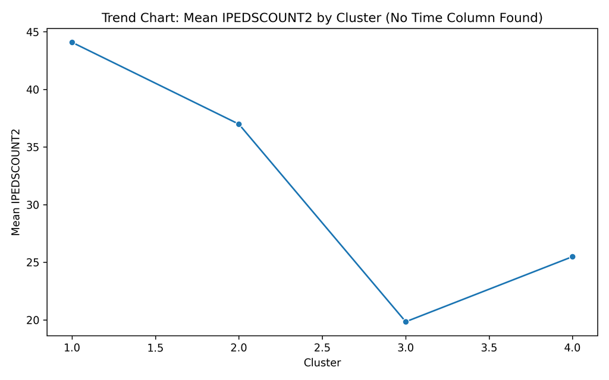

```python
print("Trend chart visualization display...")
# To Do: output the image using the display() function, for example: display(Image(filename="output/trend_chart.png"))
display(Image(filename="output/trend_chart.png"))
```

### Scatter Plot

*Hints:* A scatter plot explores the relationship between two features, grouped by clusters. Save the image as **scatter_plot.png**. Use **display()** to render the image for html file output. Do not use an html image tag in the markdown, or the image will not print in the html download.

```python
print("Creating scatter plot of two features...")
# To Do: Create a scatter plot of two features, and save it into a png file under the 'output' folder.

try:
    import os

    # Ensure output folder exists
    os.makedirs("output", exist_ok=True)

    # Align raw data to the same rows used for clustering
    scatter_df = data.iloc[:len(cluster_labels), :].copy()
    scatter_df["Cluster"] = cluster_labels

    # Select numeric columns (exclude ID-like columns if present)
    numeric_cols = scatter_df.select_dtypes(include=["int64", "float64"]).columns.tolist()
    for drop_col in ["UNITID", "OPEID6"]:
        if drop_col in numeric_cols:
            numeric_cols.remove(drop_col)

    if len(numeric_cols) < 2:
        raise ValueError("Need at least two numeric columns to create a scatter plot.")

    # Avoid low-information or code-like numeric columns
    bad_cols = {"MAIN", "CIPCODE", "CREDLEV"}
    filtered_cols = [c for c in numeric_cols if c not in bad_cols]

    # Fallback if filtering removes too many columns
    if len(filtered_cols) < 2:
        filtered_cols = numeric_cols

    # Select two features with the highest variance (most informative)
    tmp = scatter_df[filtered_cols].dropna()
    if tmp.shape[1] < 2 or tmp.empty:
        x_col, y_col = filtered_cols[0], filtered_cols[1]
    else:
        top_cols = tmp.var().sort_values(ascending=False).index.tolist()
        x_col, y_col = top_cols[0], top_cols[1]

    # Remove rows missing either feature
    plot_df = scatter_df.dropna(subset=[x_col, y_col])

    # Create scatter plot
    plt.figure(figsize=(10, 6))
    sns.scatterplot(
        data=plot_df,
        x=x_col,
        y=y_col,
        hue="Cluster",
        palette="tab10",
        alpha=0.75
    )

    plt.title(f"Scatter Plot: {x_col} vs {y_col} (Colored by Cluster)")
    plt.xlabel(x_col)
    plt.ylabel(y_col)
    plt.legend(title="Cluster")

    # Save and close figure
    scatter_path = "output/scatter_plot.png"
    plt.tight_layout()
    plt.savefig(scatter_path, dpi=300)
    plt.close()

    print(f"Scatter plot saved to: {scatter_path}")
    print("X feature:", x_col)
    print("Y feature:", y_col)

except Exception as e:
    print("Error occurred while creating/saving the scatter plot:")
    print(e)
    exit()
```

```
Creating scatter plot of two features...
Scatter plot saved to: output/scatter_plot.png
X feature: IPEDSCOUNT2
Y feature: IPEDSCOUNT1
```

```
Scatter plot visualization display...
```

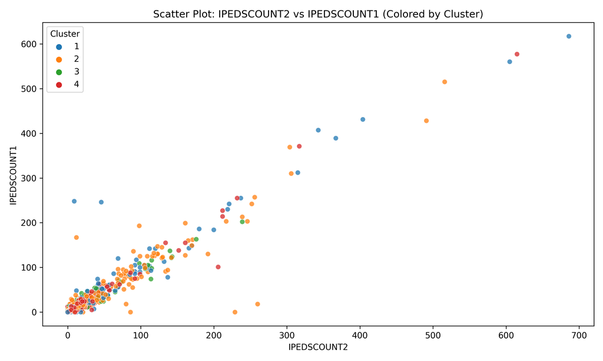

```python
print("Scatter plot visualization display...")
# To Do: output the image using the display() function, for example: display(Image(filename="output/scatter_plot.png"))
display(Image(filename="output/scatter_plot.png"))
```

## Part 2: Reflection

*This part is to be completed in a word document, using the output above to answer the topics.*

### Identify patterns in the data. Consider the following:

- Are there any clear trends, clusters, or outliers visible in your visualizations?
- Are certain variables showing consistent behavior or relationships?
- Are the patterns similar across different visualization types?

### Draw conclusions from the patterns. Consider the following:

- Are your conclusions clearly based on the patterns you observed?
- Are your findings supported by multiple visuals or data points?

### Explain how the visualizations validate your findings. Consider the following:

- Are specific chart elements (e.g., color, scale, labels) helping to highlight your findings?
- Are the insights you found something you could not easily see without the visuals?

### Write a summary of the visualization choices you made. Include the following:

- An explanation of the types of charts you used
- An explanation of the formatting decisions to support visual clarity